# Chapter 5: Classification and Regression Trees (CART)

S Zhang

2026-02-23

# 1. Introduction to Decision Trees

Decision trees partition the feature space recursively for both **regression** (continuous outcomes) and **classification** (categorical outcomes).

Advantages:

- Interpretable, no data distribution assumptions, handles mixed data types

Disadvantages:

- High variance, prone to overfitting, unstable

**CART** = Classification and Regression Trees (Breiman et al., 1984)

# 2. The Iris Dataset

We’ll use the famous `iris` dataset, which contains measurements for three species of iris flowers.

```r
data(iris)
str(iris)
```

```
## 'data.frame':    150 obs. of  5 variables:
##  $ Sepal.Length: num  5.1 4.9 4.7 4.6 5 5.4 4.6 5 4.4 4.9 ...
##  $ Sepal.Width : num  3.5 3 3.2 3.1 3.6 3.9 3.4 3.4 2.9 3.1 ...
##  $ Petal.Length: num  1.4 1.4 1.3 1.5 1.4 1.7 1.4 1.5 1.4 1.5 ...
##  $ Petal.Width : num  0.2 0.2 0.2 0.2 0.2 0.4 0.3 0.2 0.2 0.1 ...
##  $ Species     : Factor w/ 3 levels "setosa","versicolor",..: 1 1 1 1 1 1 1 1 1 1 ...
```

```r
# First few rows
head(iris) %>%
  kbl(caption = "Iris Dataset - First 6 Observations",
      align = 'c', booktabs = TRUE) %>%
  kable_styling(full_width = FALSE, position = "center")
```

Iris Dataset - First 6 Observations

| Sepal.Length | Sepal.Width | Petal.Length | Petal.Width | Species |
| --- | --- | --- | --- | --- |
| 5.1 | 3.5 | 1.4 | 0.2 | setosa |
| 4.9 | 3.0 | 1.4 | 0.2 | setosa |
| 4.7 | 3.2 | 1.3 | 0.2 | setosa |
| 4.6 | 3.1 | 1.5 | 0.2 | setosa |
| 5.0 | 3.6 | 1.4 | 0.2 | setosa |
| 5.4 | 3.9 | 1.7 | 0.4 | setosa |

```r
# Class distribution
table(iris$Species) %>%
  kbl(caption = "Class Distribution",
      align = 'c', booktabs = TRUE) %>%
  kable_styling(full_width = FALSE, position = "center")
```

Class Distribution

| Var1 | Freq |
| --- | --- |
| setosa | 50 |
| versicolor | 50 |
| virginica | 50 |

**Dataset:** 150 observations, 4 features, 3 balanced classes (50 each)

# 3. Classification Trees (Predicting Species)

## 3.1 Splitting Criteria

Classification trees use **impurity measures** to decide on splits:

**Gini Index:** $G = \sum_{k=1}^{K} \hat{p}_{mk}(1 - \hat{p}_{mk})$

**Cross-Entropy:** $D = -\sum_{k=1}^{K} \hat{p}_{mk} \log(\hat{p}_{mk})$

Lower values = better splits.

## 3.2 Fit a Classification Tree

```r
# Fit classification tree
class_tree <- rpart(Species ~ ., data = iris, method = "class")

# Display tree structure
class_tree
```

```
## n= 150
##
## node), split, n, loss, yval, (yprob)
##       * denotes terminal node
##
## 1) root 150 100 setosa (0.33333333 0.33333333 0.33333333)
##   2) Petal.Length< 2.45 50   0 setosa (1.00000000 0.00000000 0.00000000) *
##   3) Petal.Length>=2.45 100  50 versicolor (0.00000000 0.50000000 0.50000000)
##     6) Petal.Width< 1.75 54   5 versicolor (0.00000000 0.90740741 0.09259259) *
##     7) Petal.Width>=1.75 46   1 virginica (0.00000000 0.02173913 0.97826087) *
```

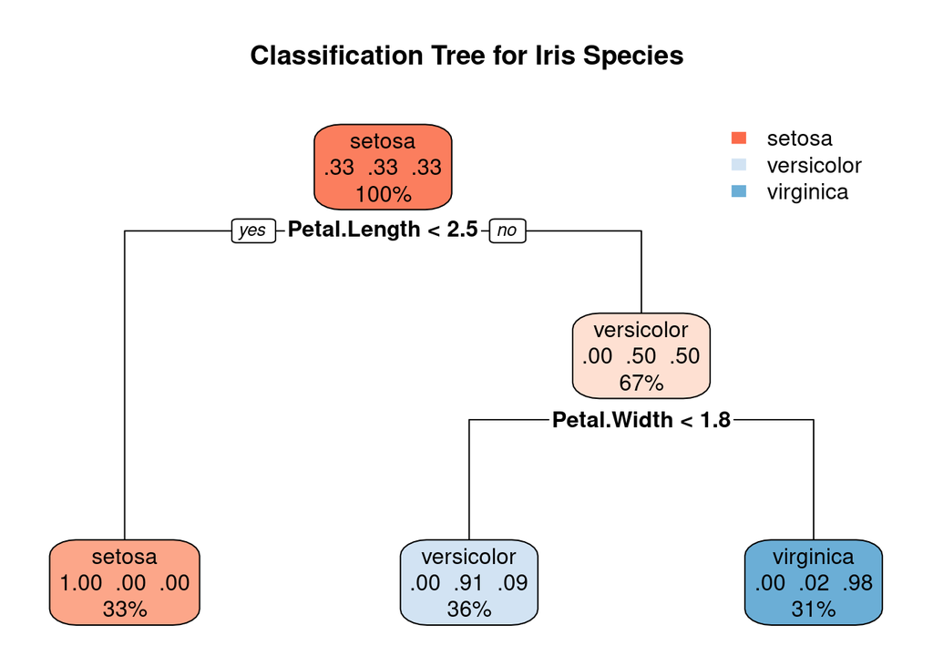

```r
# Visualize the tree
rpart.plot(class_tree, main = "Classification Tree for Iris Species",
           extra = 104,  # Show class probabilities
           box.palette = "RdBu")
```

**Interpreting the tree:**

- Each node shows the predicted class and probability
- Splits occur at values that minimize Gini impurity
- Petal length and width are the most important features

## 3.3 Prediction with Classification Trees

```r
# Predict classes
class_pred <- predict(class_tree, newdata = iris, type = "class")

# Predict probabilities
class_prob <- predict(class_tree, newdata = iris, type = "prob")
head(class_prob)
```

```
##   setosa versicolor virginica
## 1      1          0         0
## 2      1          0         0
## 3      1          0         0
## 4      1          0         0
## 5      1          0         0
## 6      1          0         0
```

```r
# Confusion matrix
cm <- table(Predicted = class_pred, Actual = iris$Species)
cm %>%
  kbl(caption = "Confusion Matrix - Classification Tree",
      align = 'c', booktabs = TRUE) %>%
  kable_styling(full_width = FALSE, position = "center")
```

Confusion Matrix - Classification Tree

|  | setosa | versicolor | virginica |
| --- | --- | --- | --- |
| setosa | 50 | 0 | 0 |
| versicolor | 0 | 49 | 5 |
| virginica | 0 | 1 | 45 |

```r
# Calculate accuracy
accuracy <- mean(class_pred == iris$Species)
cat("Training Accuracy:", round(accuracy, 4))
```

```
## Training Accuracy: 0.96
```

**Verified:** Tree achieves high accuracy on training data ✓

# 4. Train-Test Split for Honest Evaluation

```r
set.seed(123)

# Split data (70/30)
n <- nrow(iris)
train_index <- sample(1:n, size = round(0.7 * n))
train_data <- iris[train_index, ]
test_data <- iris[-train_index, ]

cat("Training observations:", nrow(train_data), "\n")
```

```
## Training observations: 105
```

```r
cat("Test observations:", nrow(test_data), "\n")
```

```
## Test observations: 45
```

```r
# Check class balance in splits
train_dist <- table(train_data$Species)
test_dist <- table(test_data$Species)

dist_df <- data.frame(
  Species = names(train_dist),
  Train = as.vector(train_dist),
  Test = as.vector(test_dist)
)

dist_df %>%
  kbl(caption = "Class Distribution in Train/Test Splits",
      align = c('l', 'c', 'c'), booktabs = TRUE) %>%
  kable_styling(full_width = FALSE, position = "center")
```

Class Distribution in Train/Test Splits

| Species | Train | Test |
| --- | --- | --- |
| setosa | 36 | 14 |
| versicolor | 32 | 18 |
| virginica | 37 | 13 |

```r
# Fit tree on training data
tree_train <- rpart(Species ~ ., data = train_data, method = "class")

# Predict on test data
test_pred <- predict(tree_train, newdata = test_data, type = "class")
test_prob <- predict(tree_train, newdata = test_data, type = "prob")

# Test accuracy
test_accuracy <- mean(test_pred == test_data$Species)
cat("Test Accuracy:", round(test_accuracy, 4))
```

```
## Test Accuracy: 0.9778
```

# 5. Tree Pruning to Avoid Overfitting

## 5.1 The Overfitting Problem

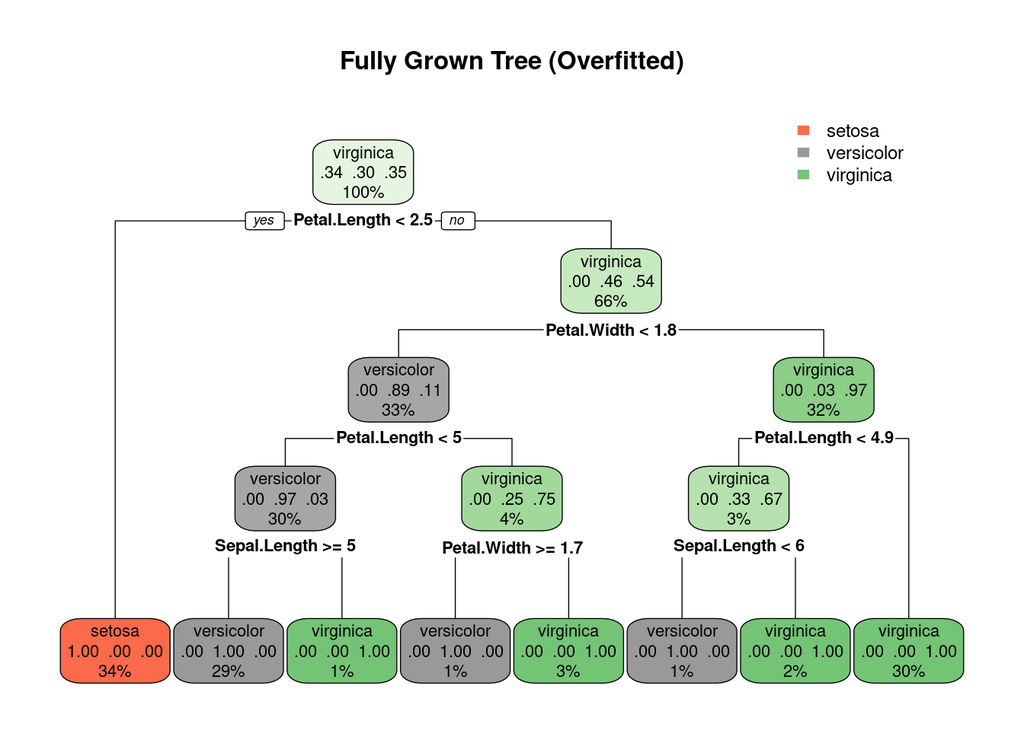

```r
# Grow a full tree (no pruning)
full_tree <- rpart(Species ~ ., data = train_data,
                   method = "class",
                   control = rpart.control(cp = 0, minsplit = 2))

rpart.plot(full_tree, main = "Fully Grown Tree (Overfitted)")
```

```r
# Check complexity
printcp(full_tree)
```

```
##
## Classification tree:
## rpart(formula = Species ~ ., data = train_data, method = "class",
##     control = rpart.control(cp = 0, minsplit = 2))
##
## Variables actually used in tree construction:
## [1] Petal.Length Petal.Width  Sepal.Length
##
## Root node error: 68/105 = 0.64762
##
## n= 105
##
##          CP nsplit rel error  xerror     xstd
## 1 0.5294118      0  1.000000 1.16176 0.065042
## 2 0.3970588      1  0.470588 0.54412 0.071987
## 3 0.0294118      2  0.073529 0.19118 0.049632
## 4 0.0147059      3  0.044118 0.13235 0.042185
## 5 0.0073529      5  0.014706 0.11765 0.039979
## 6 0.0000000      7  0.000000 0.13235 0.042185
```

## 5.2 Cost-Complexity Pruning

CART uses **cost-complexity pruning**:

$$\text{Loss} = \text{Error} + \alpha
\times |T|$$

Where $|T|$ = number of terminal nodes, $\alpha$ = complexity parameter (cp).

```r
# Fit tree with cross-validation
set.seed(123)
cv_tree <- rpart(Species ~ ., data = train_data,
                 method = "class",
                 control = rpart.control(cp = 0.01))

# View complexity parameter table
printcp(cv_tree)
```

```
##
## Classification tree:
## rpart(formula = Species ~ ., data = train_data, method = "class",
##     control = rpart.control(cp = 0.01))
##
## Variables actually used in tree construction:
## [1] Petal.Length Petal.Width
##
## Root node error: 68/105 = 0.64762
##
## n= 105
##
##        CP nsplit rel error  xerror     xstd
## 1 0.52941      0  1.000000 1.10294 0.068075
## 2 0.39706      1  0.470588 0.47059 0.069364
## 3 0.01000      2  0.073529 0.11765 0.039979
```

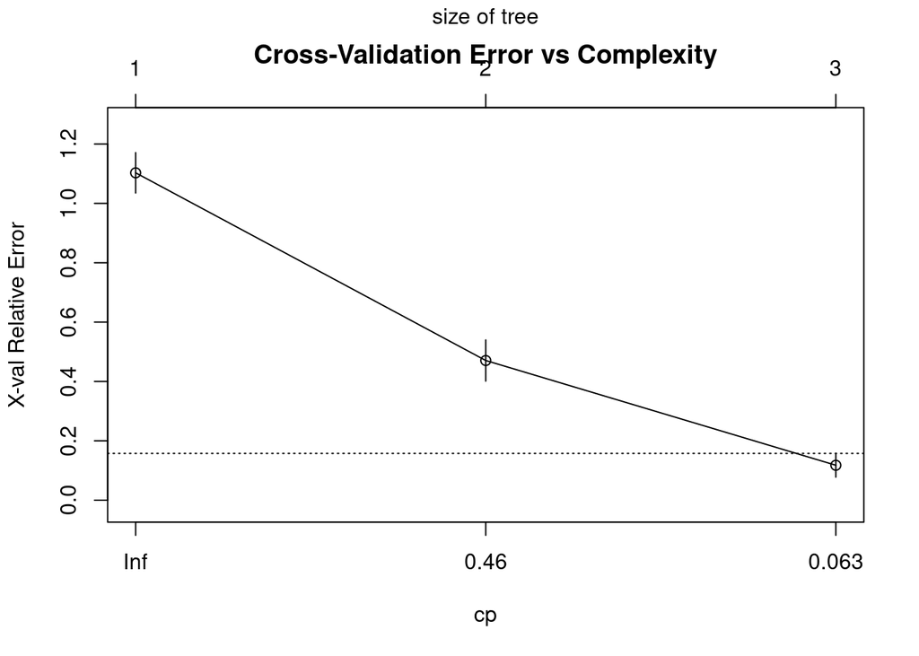

```r
# Plot cross-validation error
plotcp(cv_tree, main = "Cross-Validation Error vs Complexity")
```

```r
# Find optimal cp
cp_table <- cv_tree$cptable
optimal_cp <- cp_table[which.min(cp_table[,"xerror"]), "CP"]
optimal_cp
```

```
## [1] 0.01
```

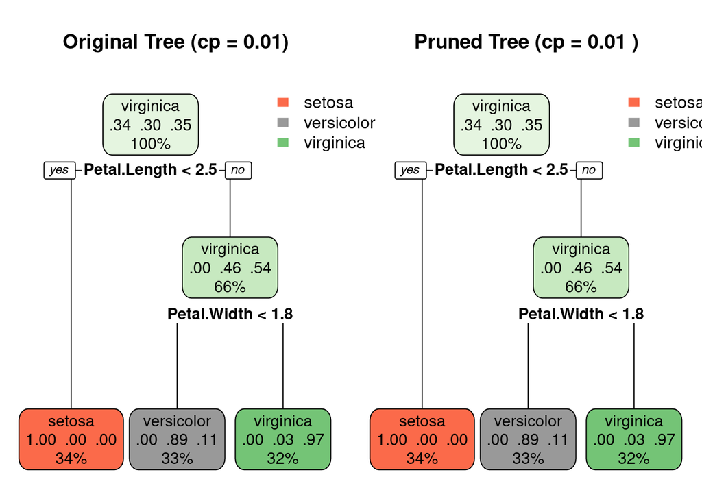

```r
# Prune tree at optimal cp
pruned_tree <- prune(cv_tree, cp = optimal_cp)

# Compare sizes
par(mfrow = c(1, 2))
rpart.plot(cv_tree, main = paste("Original Tree (cp = 0.01)"))
rpart.plot(pruned_tree, main = paste("Pruned Tree (cp =", round(optimal_cp, 4), ")"))
```

```r
par(mfrow = c(1, 1))
```

# 6. Comparing Model Performance

```r
# Predictions from different trees
full_pred <- predict(full_tree, test_data, type = "class")
pruned_pred <- predict(pruned_tree, test_data, type = "class")

# Calculate accuracies
full_acc <- mean(full_pred == test_data$Species)
pruned_acc <- mean(pruned_pred == test_data$Species)

comparison <- data.frame(
  Model = c("Full Tree", "Pruned Tree"),
  cp = c(0, round(optimal_cp, 4)),
  Size = c(
    sum(full_tree$frame$var == "<leaf>"),
    sum(pruned_tree$frame$var == "<leaf>")
  ),
  Test_Accuracy = round(c(full_acc, pruned_acc), 4)
)

comparison %>%
  kbl(caption = "Full vs Pruned Tree Comparison",
      align = c('l', 'c', 'c', 'c'), booktabs = TRUE) %>%
  kable_styling(full_width = FALSE, position = "center") %>%
  row_spec(which.max(comparison$Test_Accuracy), bold = TRUE, background = "#e8f5e9")
```

Full vs Pruned Tree Comparison

| Model | cp | Size | Test_Accuracy |
| --- | --- | --- | --- |
| Full Tree | 0.00 | 8 | 0.9556 |
| Pruned Tree | 0.01 | 3 | 0.9778 |

The pruned tree may have slightly lower training accuracy but should generalize better to new data!

# 7. Variable Importance

```r
# Get variable importance
importance <- data.frame(
  Variable = names(tree_train$variable.importance),
  Importance = round(tree_train$variable.importance, 2)
) %>% arrange(desc(Importance))

importance %>%
  kbl(caption = "Variable Importance Scores",
      align = c('l', 'c'), booktabs = TRUE) %>%
  kable_styling(full_width = FALSE, position = "center")
```

Variable Importance Scores

|  | Variable | Importance |
| --- | --- | --- |
| Petal.Width | Petal.Width | 60.84 |
| Petal.Length | Petal.Length | 56.38 |
| Sepal.Length | Sepal.Length | 37.32 |
| Sepal.Width | Sepal.Width | 23.48 |

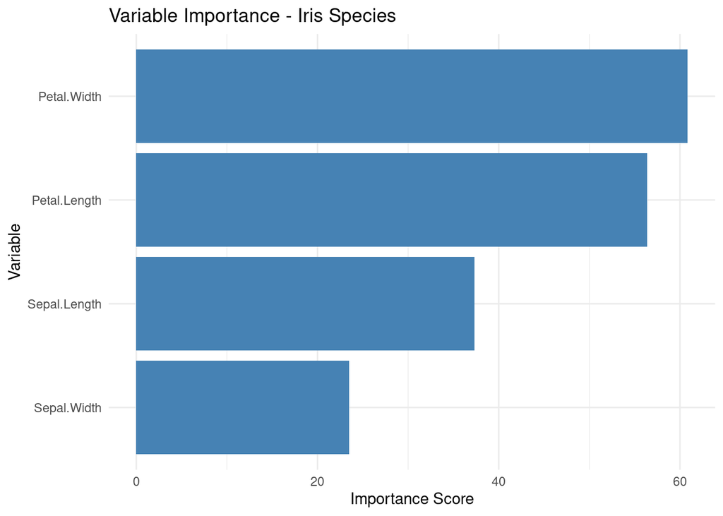

```r
# Visualize importance
ggplot(importance, aes(x = reorder(Variable, Importance), y = Importance)) +
  geom_col(fill = "steelblue") +
  coord_flip() +
  labs(title = "Variable Importance - Iris Species",
       x = "Variable", y = "Importance Score") +
  theme_minimal()
```

**Petal measurements dominate** – this matches botanical knowledge that petal dimensions best distinguish iris species.

# 8. Multi-Class ROC (One-vs-Rest)

For multi-class problems, we can create ROC curves for each class.

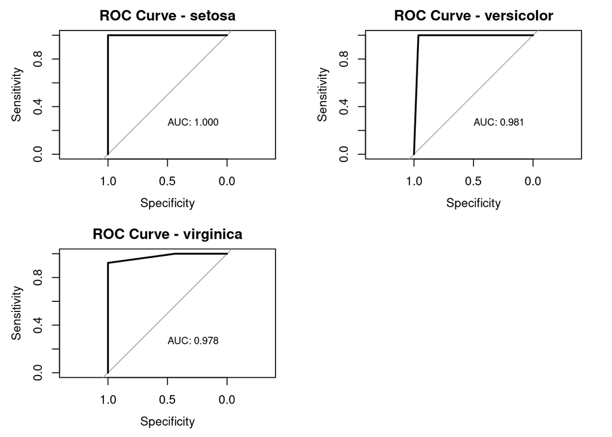

```r
# Probability predictions
test_prob <- predict(tree_train, test_data, type = "prob")

# Create ROC curves for each class
par(mfrow = c(2, 2))
for(i in 1:3) {
  class_name <- levels(test_data$Species)[i]
  # Create binary outcome for this class
  binary_outcome <- ifelse(test_data$Species == class_name, 1, 0)
  roc_obj <- roc(binary_outcome, test_prob[, i])
  plot(roc_obj, main = paste("ROC Curve -", class_name),
       print.auc = TRUE, print.auc.y = 0.3)
}
par(mfrow = c(1, 1))
```

# 9. Tuning the Complexity Parameter

```r
set.seed(123)
cp_values <- seq(0.001, 0.1, length = 15)
cv_results <- data.frame(cp = cp_values, CV_Error = NA)

for(i in 1:length(cp_values)) {
  # 5-fold CV
  folds <- sample(rep(1:5, length.out = nrow(train_data)))
  fold_errors <- c()

  for(f in 1:5) {
    cv_train <- train_data[folds != f, ]
    cv_val <- train_data[folds == f, ]

    tree <- rpart(Species ~ ., data = cv_train, method = "class",
                  control = rpart.control(cp = cp_values[i]))
    pred <- predict(tree, cv_val, type = "class")
    fold_errors[f] <- 1 - mean(pred == cv_val$Species)
  }

  cv_results$CV_Error[i] <- mean(fold_errors)
}
```

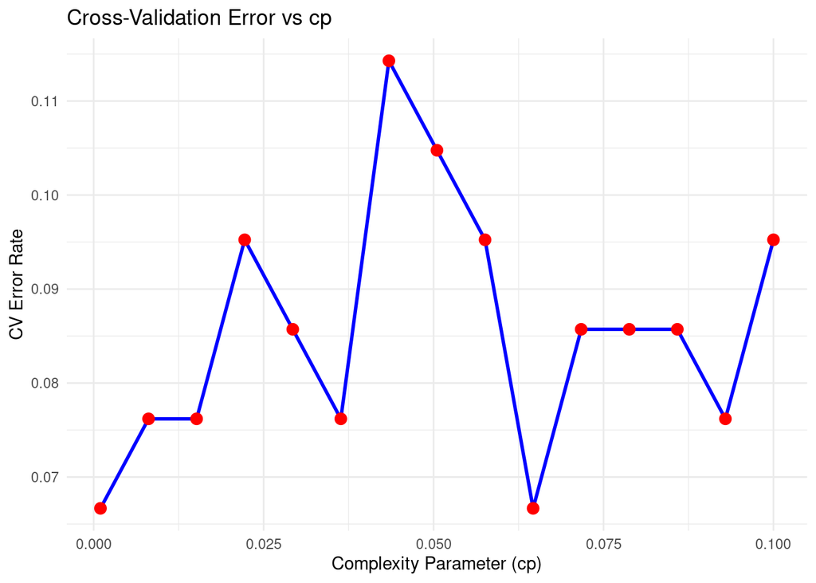

```r
# Plot CV results
ggplot(cv_results, aes(x = cp, y = CV_Error)) +
  geom_line(color = "blue", size = 1) +
  geom_point(size = 3, color = "red") +
  labs(title = "Cross-Validation Error vs cp",
       x = "Complexity Parameter (cp)", y = "CV Error Rate") +
  theme_minimal()
```

```r
# Best cp
best_cp <- cv_results$cp[which.min(cv_results$CV_Error)]
cat("Best cp:", round(best_cp, 4))
```

```
## Best cp: 0.001
```

# 10. Final Model with Optimal cp

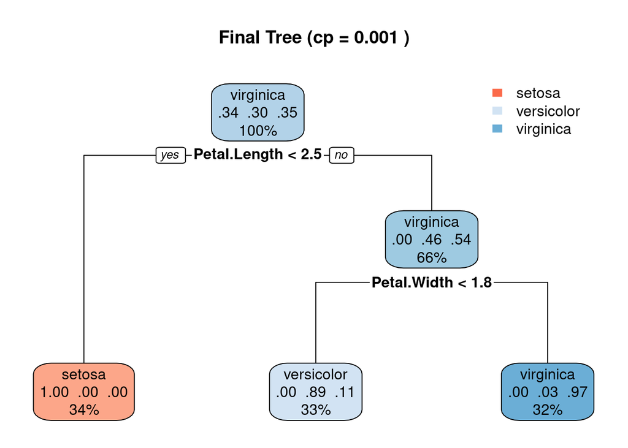

```r
# Final model
final_tree <- rpart(Species ~ ., data = train_data, method = "class",
                    control = rpart.control(cp = best_cp))

rpart.plot(final_tree, main = paste("Final Tree (cp =", round(best_cp, 4), ")"),
           extra = 104, box.palette = "RdBu")
```

```r
# Final test performance
final_pred <- predict(final_tree, test_data, type = "class")
final_acc <- mean(final_pred == test_data$Species)

# Confusion matrix
final_cm <- table(Predicted = final_pred, Actual = test_data$Species)
final_cm %>%
  kbl(caption = paste("Final Model - Test Confusion Matrix (Accuracy:",
                      round(final_acc, 4), ")"),
      align = 'c', booktabs = TRUE) %>%
  kable_styling(full_width = FALSE, position = "center")
```

Final Model - Test Confusion Matrix (Accuracy: 0.9778 )

|  | setosa | versicolor | virginica |
| --- | --- | --- | --- |
| setosa | 14 | 0 | 0 |
| versicolor | 0 | 18 | 1 |
| virginica | 0 | 0 | 12 |

# 11. Advantages & Disadvantages Summary

| Advantages | Disadvantages |
| --- | --- |
| Easy to interpret | High variance |
| Handles mixed data | Instability |
| Non-parametric | Greedy algorithm |
| Automatic feature selection | Can overfit without pruning |

**Biggest limitation:** Trees are high-variance. Small data changes can produce completely different trees.

# 12. Key Takeaways

**Essential concepts:**

1. Trees partition space recursively based on impurity measures (Gini/Entropy)
2. **Pruning** with cost-complexity parameter (cp) prevents overfitting
3. Cross-validation selects optimal cp
4. Variable importance shows predictor influence
5. Petal measurements are key for iris classification
6. Trees are interpretable but unstable
7. **Ensembles** (random forests, boosting) fix instability – next chapter!